# Analisi dei dati relativi alle corse di Uber nel periodo aprile/settembre 2014

## Introduzione

In questo progetto andrò ad analizzare sotto vari aspetti i dati relativi alle corse di Uber avvenute nel periodo tra aprile e settembre del 2014. Nello specifico svolgerò varie analisi sui dati sia dal punto di vista temporale che da quello spaziale.

## Analisi temporale - Corse per ora e mese

Dal seguente grafico si può notare come le corse si intensifichino durante le prime ore del mattino (7-8) e in particolar modo verso fine pomeriggio (16-18).

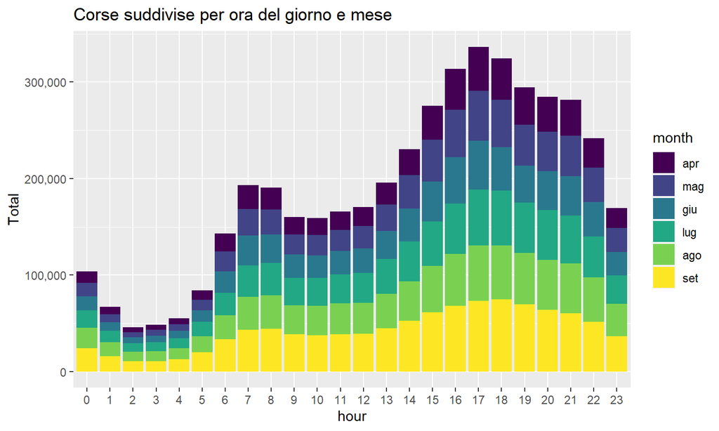

## Corse per giorno del mese

Possiamo notare come la distribuzione delle corse durante i vari giorni del mese sia quasi uniforme, fatta eccezione per il trentunesimo giorno del mese, dove viene registrato un netto calo.

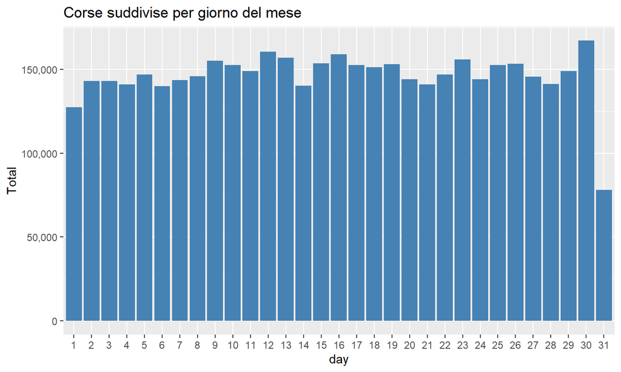

## Corse per giorno e mese

Nel seguente grafico possiamo vedere il numero di corse, suddivise per mese e per giorno della settimana.

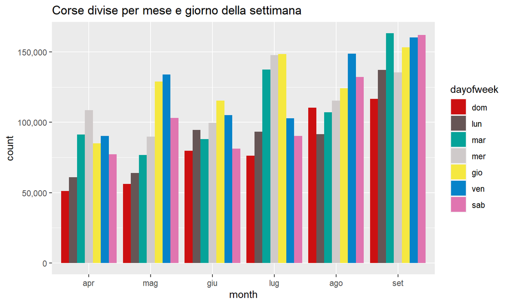

## Corse per mese

Possiamo notare come il numero delle corse aumenti all’avanzare dei mesi dell’anno, con un netto aumento nel mese di settembre rispetto ai mesi precedenti.

|  | month | Total |
| --- | --- | --- |
| 1 | apr | 564516 |
| 2 | mag | 652435 |
| 3 | giu | 663844 |
| 4 | lug | 796121 |
| 5 | ago | 829275 |
| 6 | set | 1028136 |

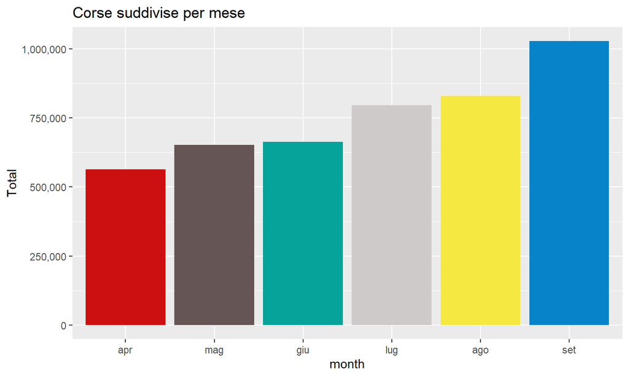

## Compagnia di registrazione del veicolo

Nello stato di New York ogni veicolo destinato al servizio di noleggio con conducente deve essere registrato presso una compagnia autorizzata che gli consente di operare sul territorio. Nel seguente grafico possiamo distinguere le varie corse sulla base della compagnia a cui è riferito il veicolo utilizzato.

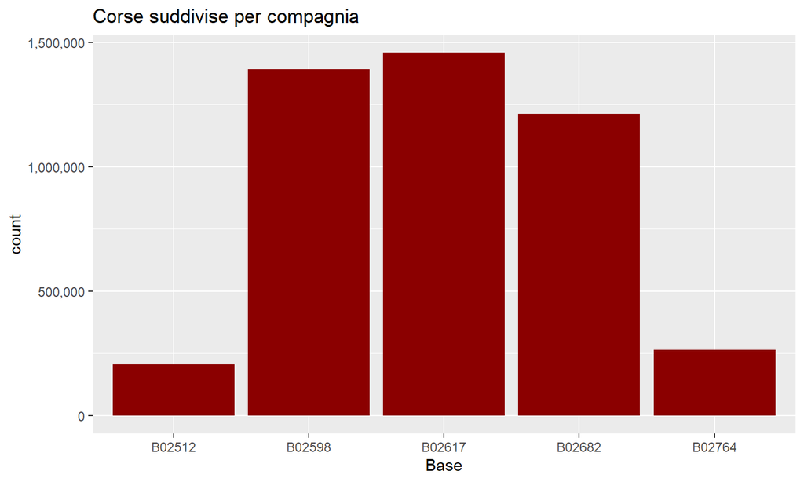

## Corse per mese e compagnia di registrazione

In questo grafico possiamo vedere il numero di corse effettuate suddivise per compagnia di registrazione del veicolo e mese dell’anno.

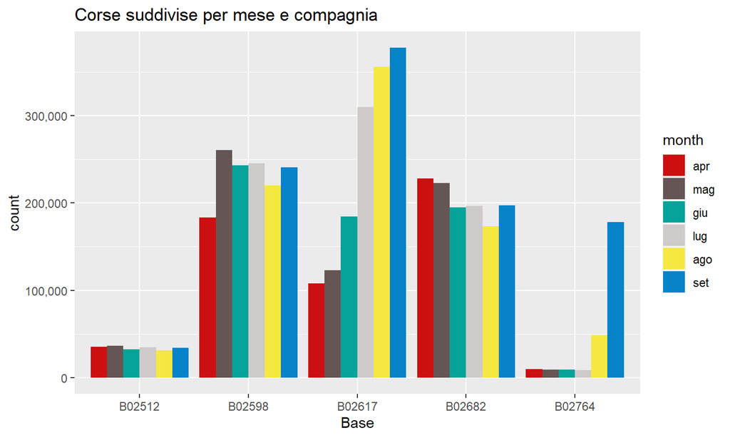

## Corse per giorno della settimana e compagnia di registrazione

Segue un grafico analogo al precedente ma con il totale di corse suddiviso per compagnia di registrazione del veicolo e giorno della settimana.

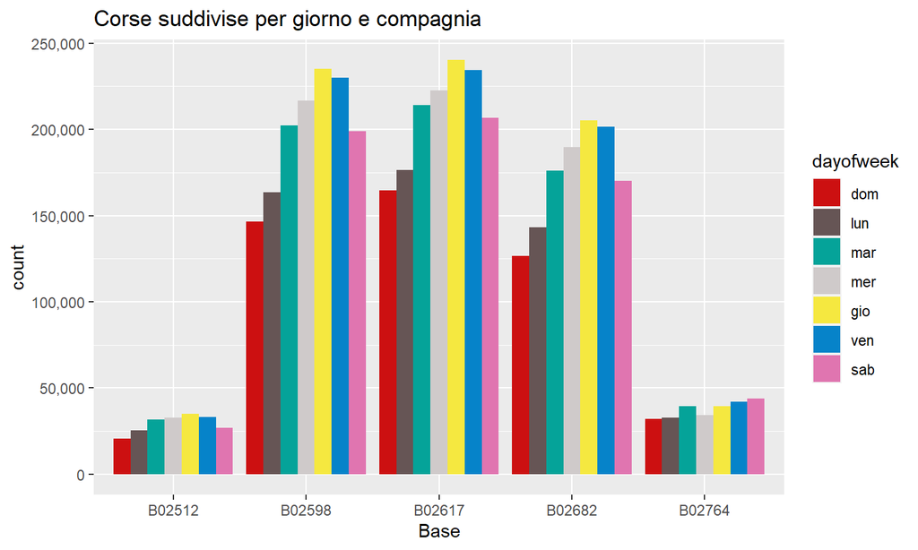

## Heat Map - corse per mese e ora

Di seguito possiamo vedere una tipologia di grafico con un aspetto differente dalle precedenti, questa heat map mostra quante corse si sono svolte suddividendole per mese e ora del giorno, mostrando graficamente l’intensità di ogni possibile intersezione.

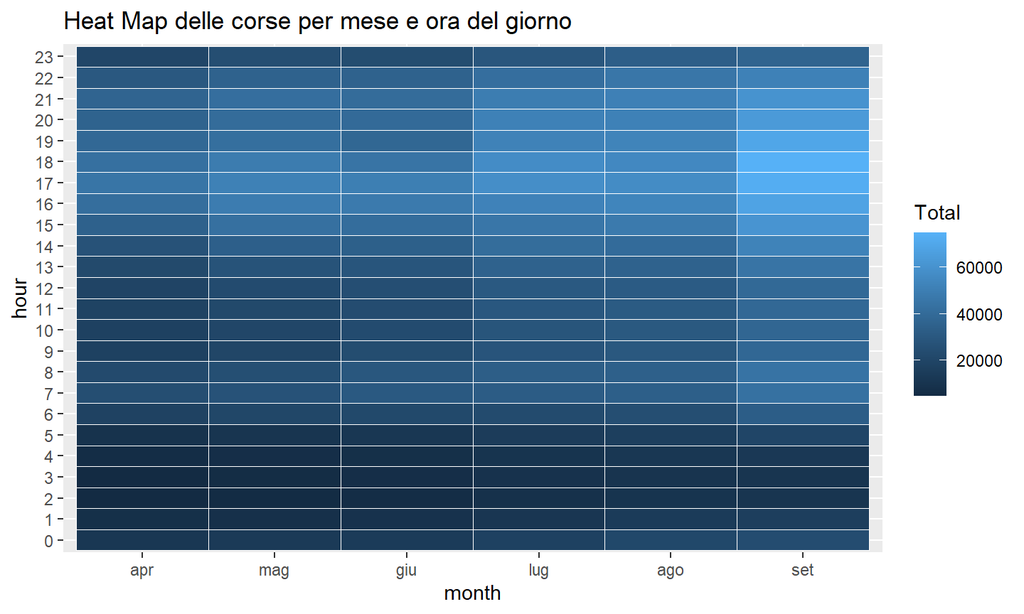

## Heat Map - corse per mese e giorno

In questa heat map andiamo invece ad analizzare la quantità di corse divisa per mese e giorno del mese. Possiamo notare come ci sia un notevole decremento delle corse durante le festività, in particolare a ridosso dell’Indipendence Day (4 luglio) e del Memorial Day (26 maggio).

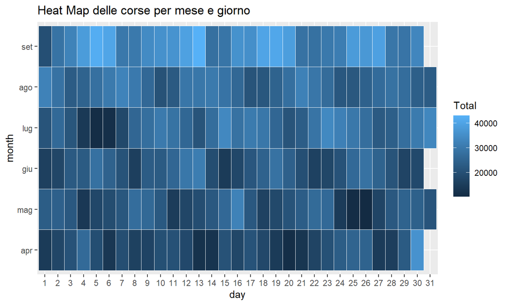

## Heat Map - corse per giorno della settimana e ora

Questa heat map ci consente di analizzare il numero di corse che avviene in ogni fascia oraria del giorno in rapporto al giorno della settimana in cui ci si trova. Come visto in un precedente grafico possiamo anche qui notare un notevole aumento delle corse durante le prime ore del mattino, nella fine del pomeriggio e nelle ore serali, fatta eccezione per sabato e domenica che seguono un andamento diverso.

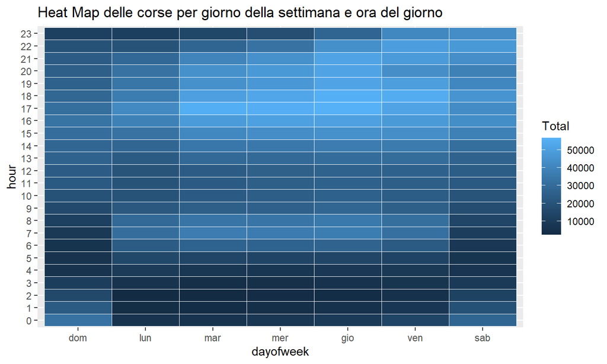

## Analisi spaziale - mappa delle corse

Di seguito possiamo vedere un grafico dove sono state marcate le varie posizioni di partenza di ciascuna corsa presente nel dataset. I vari colori distinguono la compagnia dov’è registrato il veicolo che ha effettuato la corsa.

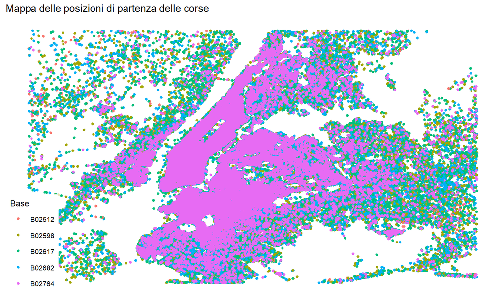